# Day 8 - Final Exercises

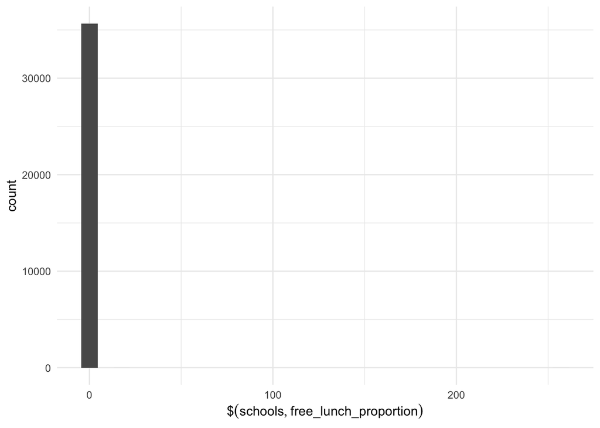

```r
# free lunch program
schools %>% create_hist(schools$free_lunch_proportion)
```

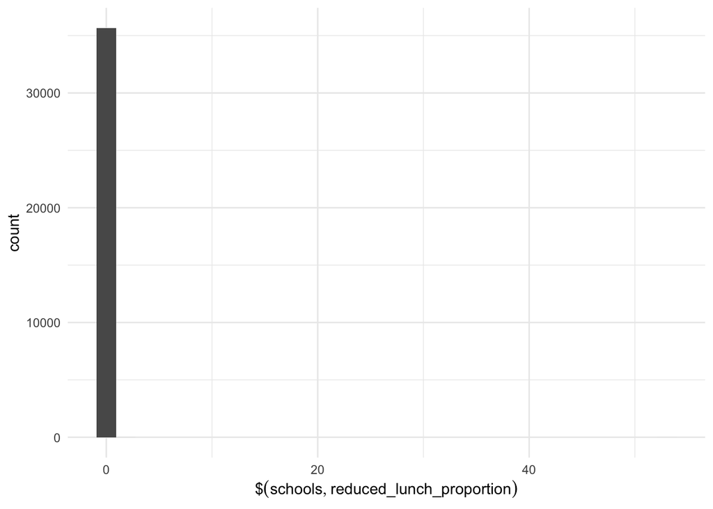

```r
# reduced lunch program
schools %>% create_hist(schools$reduced_lunch_proportion)
```

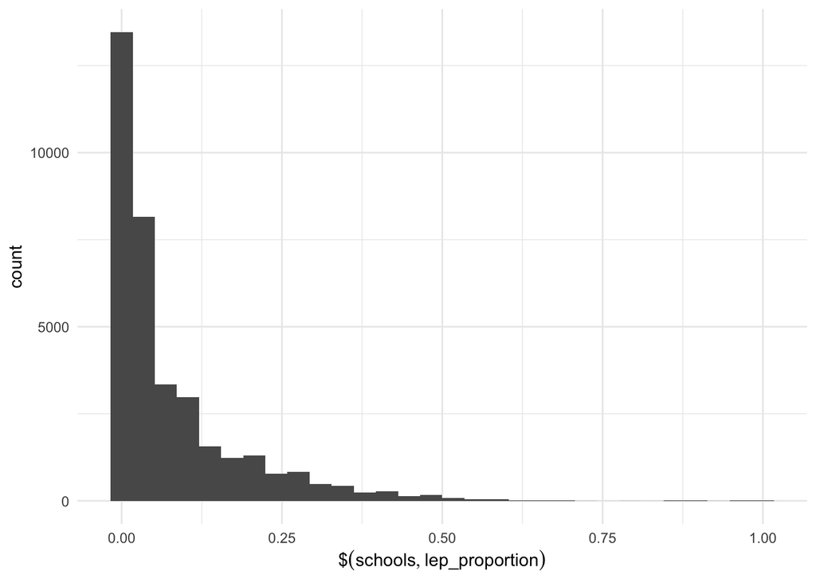

```r
# limited english proficiency proportion
schools %>% create_hist(schools$lep_proportion)
```

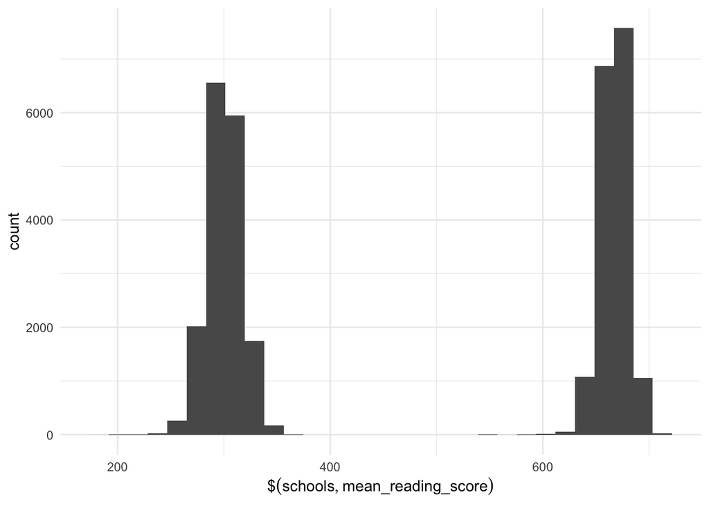

```r
# avg reading scores
schools %>% create_hist(schools$mean_reading_score)
```

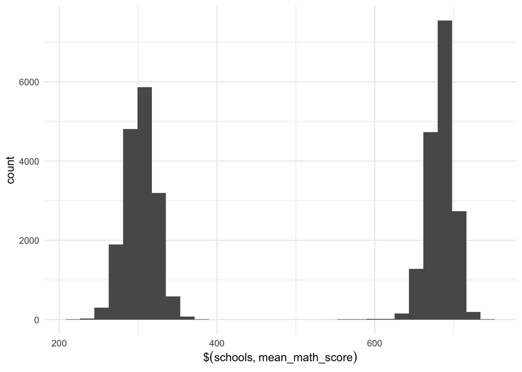

```r
# avg math scores
schools %>% create_hist(schools$mean_math_score)
```

Second, the `counties` dataset:

```r
# distribution of variables:

# counties
counties %>%
  group_by(county_name) %>%
  summarize(count = n())
```

```
## # A tibble: 62 x 2
##    county_name count
##    <chr>       <int>
##  1 ALBANY          8
##  2 ALLEGANY        8
##  3 BRONX           8
##  4 BROOME          8
##  5 CATTARAUGUS     8
##  6 CAYUGA          8
##  7 CHAUTAUQUA      8
##  8 CHEMUNG         8
##  9 CHENANGO        8
## 10 CLINTON         8
## # … with 52 more rows
```

```r
# years of available data
counties %>%
  group_by(year) %>%
  summarize(count = n())
```

```
## # A tibble: 8 x 2
##    year count
##   <dbl> <int>
## 1  2009    62
## 2  2010    62
## 3  2011    62
## 4  2012    62
## 5  2013    62
## 6  2014    62
## 7  2015    62
## 8  2016    62
```

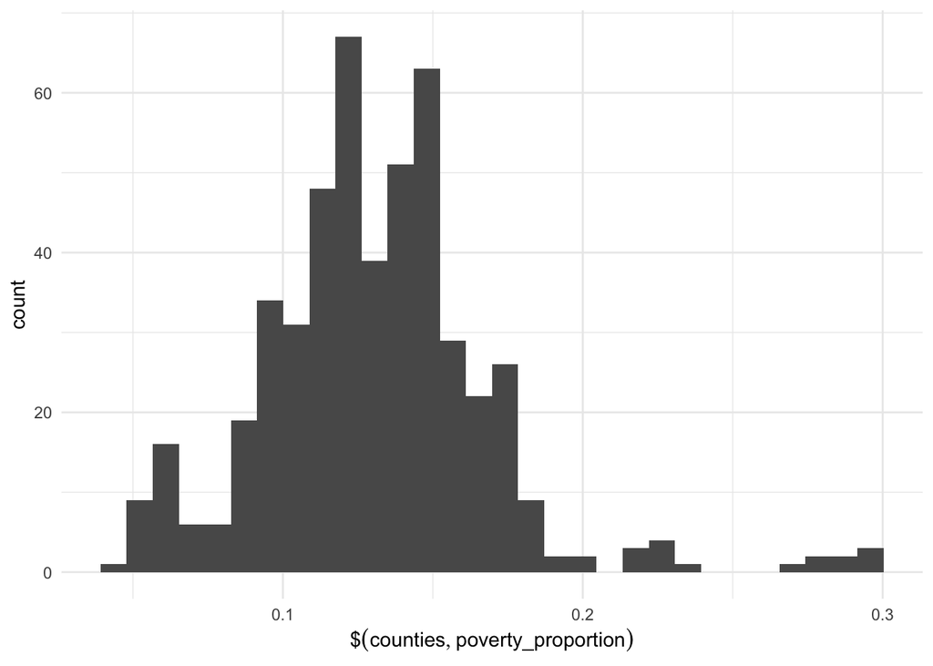

```r
# poverty_proportion
counties %>% create_hist(counties$poverty_proportion)
```

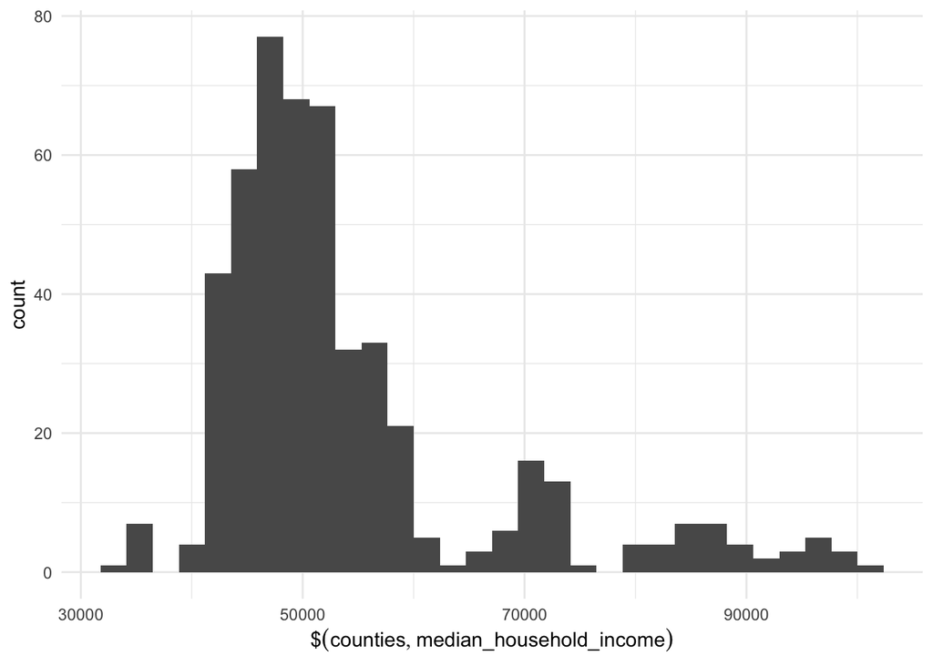

```r
# median household incomes
counties %>% create_hist(counties$median_household_income)
```

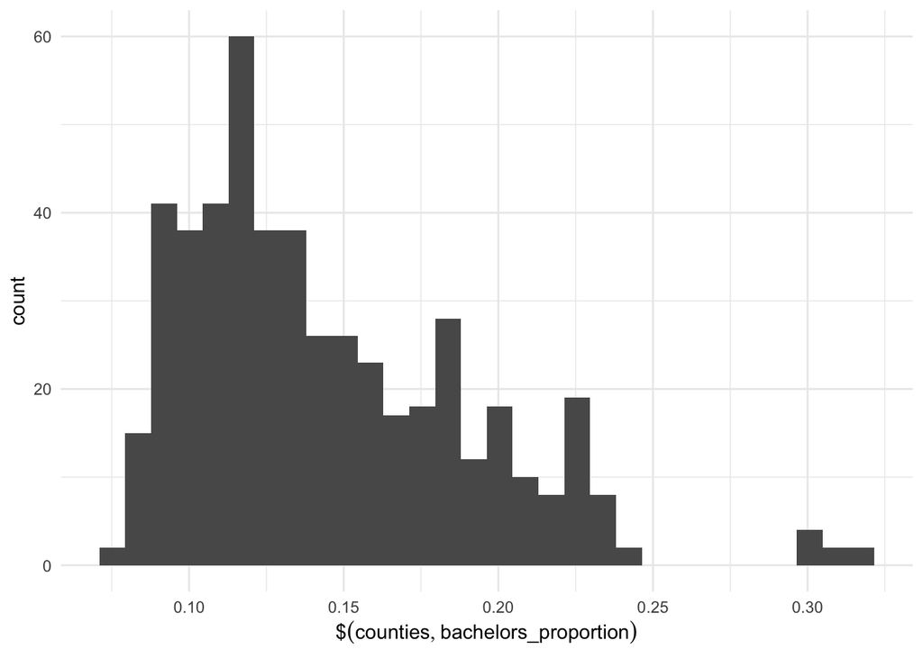

```r
# bachelors_proportion
counties %>% create_hist(counties$bachelors_proportion)
```

#### Task 3: Recoding and variable manipulation

1. Deal with missing values, which are currently coded as `-99`.
2. Create a categorical variable that groups counties into “high”, “medium”, and “low” poverty groups. Decide how you want to split up the groups and briefly explain your decision.
3. The tests that the NYS Department of Education administers changes from time to time, so scale scores are not directly comparable year-to-year. Create a new variable that is the standardized z-score for math and English Language Arts (ELA) for each year (hint: group by year and use the `scale()` function)
4. Missing values

Which rows contain missing values (“-99”)?

```r
schools_raw %>%
  select(-school_cd) %>%
  filter_all(any_vars(str_detect(., "-99")))
```

```
## # A tibble: 2,226 x 11
##    school_name district_name county_name region  year total_enroll
##    <chr>       <chr>         <chr>       <chr>  <dbl>        <dbl>
##  1 HENRY JOHN… <NA>          ALBANY      CAPIT…  2008          112
##  2 HENRY JOHN… <NA>          ALBANY      CAPIT…  2009          201
##  3 ALBANY COM… <NA>          ALBANY      CAPIT…  2008          167
##  4 BLUE CREEK… -99           -99         -99     2008          -99
##  5 BOGHT HILL… -99           -99         -99     2008          -99
##  6 FORTS FERR… -99           -99         -99     2008          -99
##  7 LATHAM RID… -99           -99         -99     2008          -99
##  8 LOUDONVILL… -99           -99         -99     2008          -99
##  9 SOUTHGATE … -99           -99         -99     2008          -99
## 10 MAPLEWOOD … -99           -99         -99     2008          -99
## # … with 2,216 more rows, and 5 more variables: per_free_lunch <dbl>,
## #   per_reduced_lunch <dbl>, per_lep <dbl>, mean_ela_score <dbl>,
## #   mean_math_score <dbl>
```

```r
counties_raw %>%
  filter_all(any_vars(str_detect(., "-99")))
```

```
## # A tibble: 0 x 5
## # … with 5 variables: county_name <chr>, year <dbl>, county_per_poverty <dbl>,
## #   median_household_income <dbl>, county_per_bach <dbl>
```

There are only a small subset of rows with `district_name == "-99"`. These are also the only records with `county_name = "-99"` or `region == "-99"`.

There are also a small group with no enrollment data. These rows also miss free lunch data and more.

```r
schools_raw %>%
  filter(total_enroll == "-99")
```

```
## # A tibble: 13 x 12
##    school_cd school_name district_name county_name region  year total_enroll
##    <chr>     <chr>       <chr>         <chr>       <chr>  <dbl>        <dbl>
##  1 01060506… BLUE CREEK… -99           -99         -99     2008          -99
##  2 01060506… BOGHT HILL… -99           -99         -99     2008          -99
##  3 01060506… FORTS FERR… -99           -99         -99     2008          -99
##  4 01060506… LATHAM RID… -99           -99         -99     2008          -99
##  5 01060506… LOUDONVILL… -99           -99         -99     2008          -99
##  6 01060506… SOUTHGATE … -99           -99         -99     2008          -99
##  7 01062208… MAPLEWOOD … -99           -99         -99     2008          -99
##  8 31010086… ROSS GLOBA… <NA>          NEW YORK    NEW Y…  2011          -99
##  9 33130086… ACHIEVEMEN… <NA>          KINGS       NEW Y…  2010          -99
## 10 33230086… LEADERSHIP… <NA>          KINGS       NEW Y…  2010          -99
## 11 57010104… VALLEY ELE… ADDISON CENT… STEUBEN     SOUTH…  2015          -99
## 12 66041002… ZICCOLELLA… GREENBURGH-G… WESTCHESTER HUDSO…  2015          -99
## 13 66150001… URIAH HILL… PEEKSKILL CI… WESTCHESTER HUDSO…  2015          -99
## # … with 5 more variables: per_free_lunch <dbl>, per_reduced_lunch <dbl>,
## #   per_lep <dbl>, mean_ela_score <dbl>, mean_math_score <dbl>
```

It doesn’t make sense to keep any records if all the numerical info is unavailable. So drop the rows with basically only school_name and year:

```r
# preview and confirm the rows we want to drop
schools %>%
  filter(is.na(total_enrollment),
         is.na(mean_reading_score))
```

```
## # A tibble: 10 x 12
##    school_id school_name district_name county_name region  year total_enrollment
##    <chr>     <chr>       <chr>         <chr>       <chr>  <dbl>            <dbl>
##  1 01060506… BLUE CREEK… <NA>          <NA>        <NA>    2008               NA
##  2 01060506… BOGHT HILL… <NA>          <NA>        <NA>    2008               NA
##  3 01060506… FORTS FERR… <NA>          <NA>        <NA>    2008               NA
##  4 01060506… LATHAM RID… <NA>          <NA>        <NA>    2008               NA
##  5 01060506… LOUDONVILL… <NA>          <NA>        <NA>    2008               NA
##  6 01060506… SOUTHGATE … <NA>          <NA>        <NA>    2008               NA
##  7 01062208… MAPLEWOOD … <NA>          <NA>        <NA>    2008               NA
##  8 33230086… LEADERSHIP… <NA>          KINGS       NEW Y…  2010               NA
##  9 57010104… VALLEY ELE… ADDISON CENT… STEUBEN     SOUTH…  2015               NA
## 10 66150001… URIAH HILL… PEEKSKILL CI… WESTCHESTER HUDSO…  2015               NA
## # … with 5 more variables: free_lunch_proportion <dbl>,
## #   reduced_lunch_proportion <dbl>, lep_proportion <dbl>,
## #   mean_reading_score <dbl>, mean_math_score <dbl>
```

```r
# drop in the primary table
# the converse of (A and B) is (!A or !B)
schools <- schools %>%
  filter(!is.na(total_enrollment))
```

In order to merge the `schools` dataset with `counties`, we’re going to need `county_name` to be populated.

```r
# preview the rows to drop
schools %>%
  filter(is.na(county_name))
```

```
## # A tibble: 12 x 12
##    school_id school_name district_name county_name region  year total_enrollment
##    <chr>     <chr>       <chr>         <chr>       <chr>  <dbl>            <dbl>
##  1 31010086… NYC CHARTE… <NA>          <NA>        <NA>    2017               99
##  2 31020086… GREAT OAKS… <NA>          <NA>        <NA>    2015              196
##  3 31020086… SUCCESS AC… <NA>          <NA>        <NA>    2015              176
##  4 31060086… GLOBAL COM… <NA>          <NA>        <NA>    2015              284
##  5 31060086… AMBER CHAR… <NA>          <NA>        <NA>    2017              131
##  6 32070086… METROPOLIT… <NA>          <NA>        <NA>    2014              303
##  7 32070086… BOYS PREP … <NA>          <NA>        <NA>    2015              142
##  8 32090086… GRAND CONC… <NA>          <NA>        <NA>    2015              389
##  9 33130086… BROOKLYN U… <NA>          <NA>        <NA>    2015              202
## 10 33140086… CENTRAL BR… <NA>          <NA>        <NA>    2015              166
## 11 33230086… CENTRAL BR… <NA>          <NA>        <NA>    2017              346
## 12 34270086… SUCCESS AC… <NA>          <NA>        <NA>    2015              184
## # … with 5 more variables: free_lunch_proportion <dbl>,
## #   reduced_lunch_proportion <dbl>, lep_proportion <dbl>,
## #   mean_reading_score <dbl>, mean_math_score <dbl>
```

```r
# drop from the primary table
schools <- schools %>%
  drop_na(county_name)
```

Additionally, since we are interested in analyzing the relationship between poverty, lunch programs, and test performance, we need only the entries which do not contain NA for these columns.

```r
# which features have this stricter requirement of non-missing values?
vars_requiring_values <- c("free_lunch_proportion", "reduced_lunch_proportion", "mean_reading_score", "mean_math_score")

schools <- schools %>%
  drop_na(all_of(vars_requiring_values))
```

Looks like we are already good on this front. Perfect. So where else still contains missing values?

```r
colSums(is.na(schools))
```

```
##                school_id              school_name            district_name
##                        0                        0                     1501
##              county_name                   region                     year
##                        0                        0                        0
##         total_enrollment    free_lunch_proportion reduced_lunch_proportion
##                        0                        0                        0
##           lep_proportion       mean_reading_score          mean_math_score
##                        0                        0                        0
```

Finally, `district_name`. Does this column have any significance for our project?

```r
schools %>%
  filter(is.na(district_name)) %>%
  group_by(school_name) %>%
  summarize(count = n())
```

```
## # A tibble: 263 x 2
##    school_name                                    count
##    <chr>                                          <int>
##  1 ACADEMIC LEADERSHIP CHARTER SCHOOL                 6
##  2 ACADEMY CHARTER SCHOOL                             7
##  3 ACADEMY OF THE CITY CHARTER SCHOOL                 4
##  4 ACHIEVEMENT ACADEMY CHARTER SCHOOL                 6
##  5 ACHIEVEMENT FIRST APOLLO CHARTER SCHOOL            5
##  6 ACHIEVEMENT FIRST ASPIRE CHARTER SCHOOL            2
##  7 ACHIEVEMENT FIRST BROWNSVILLE CHARTER SCHOOL       7
##  8 ACHIEVEMENT FIRST BUSHWICK CHARTER SCHOOL          9
##  9 ACHIEVEMENT FIRST CROWN HEIGHTS CHARTER SCHOOL    10
## 10 ACHIEVEMENT FIRST EAST NEW YORK CHARTER SCHOOL    10
## # … with 253 more rows
```

It seems like they are almost exclusively charter schools, which are not confined to a single school district (rather, they typically have state or sometimes city requirements to attend). So we can leave them be for now.

2. Poverty Levels

Based on the information in the `counties` table, unfortunately it is difficult to get an accurate representation of the level of poverty in the county—the poverty line in the United States is dependent on the number of people in the household, but this information is not available in our dataset.

[One definition of poverty severity](https://en.wikipedia.org/wiki/Concentrated_poverty#History_of_concentrated_poverty_in_the_United_States) is the frequency with which poverty is experienced; in other words, the proportion of residents below the poverty line. Fortunately, our `counties` dataset provides this information in the `poverty_proportion` field.

Although the Wikipedia article indicates they are disputed and/or arbitrary, we can use the following cutoffs:

- High (“extreme”) poverty: 40% and above
- Medium: 20-39%
- Low: below 20%

In addition, I will rename the categories to prevent confusion; “low” poverty actually corresponds to high income, and “high” poverty actually corresponds to low income. Since it is a hardship, I will use “low”, “moderate,” and “severe” instead.

```r
counties <- transform(counties,
                      poverty_group = cut(poverty_proportion,
                                          breaks = c(-Inf, 0.20, 0.40, Inf),
                                          labels = c("low", "moderate", "severe")))

counties
```

```
##        county_name year poverty_proportion median_household_income
## 1           ALBANY 2009         0.11835115                   55350
## 2           ALBANY 2010         0.11940519                   56090
## 3           ALBANY 2011         0.12072431                   57715
## 4           ALBANY 2012         0.12375251                   59359
## 5           ALBANY 2013         0.12297276                   59394
## 6           ALBANY 2014         0.12861782                   59940
## 7           ALBANY 2015         0.12797963                   59887
## 8           ALBANY 2016         0.12260508                   60904
## 9         ALLEGANY 2009         0.15215323                   40917
## 10        ALLEGANY 2010         0.14919051                   41305
## 11        ALLEGANY 2011         0.14839460                   41900
## 12        ALLEGANY 2012         0.15289637                   42095
## 13        ALLEGANY 2013         0.14745567                   42445
## 14        ALLEGANY 2014         0.15245830                   42726
```

[output cut: 979 more lines]

3. Scale math and reading scores for each year

Since standardized tests can and do change each year they are administered, we will scale the scores of each year to correct for any bias (i.e. any exceptionally difficult or easy tests).

```r
# passing no arguments is equivalent to standard z-distribution scaling
standardized_test_scores <- schools %>%
  group_by(year) %>%
  transmute(mean_math_score = mean_math_score,       # keep for reference against standardized score
            mean_reading_score = mean_reading_score, # keep for reference against standardized score
            standardized_math_score = scale(mean_math_score),
            standardized_reading_score = scale(mean_reading_score))

schools <- left_join(schools, standardized_test_scores, by = c("year", "mean_reading_score", "mean_math_score"))

schools
```

```
## # A tibble: 40,817 x 14
##    school_id school_name district_name county_name region  year total_enrollment
##    <chr>     <chr>       <chr>         <chr>       <chr>  <dbl>            <dbl>
##  1 01010001… MONTESSORI… ALBANY CITY … ALBANY      CAPIT…  2008              316
##  2 01010001… MONTESSORI… ALBANY CITY … ALBANY      CAPIT…  2009              312
##  3 01010001… MONTESSORI… ALBANY CITY … ALBANY      CAPIT…  2010              300
##  4 01010001… MONTESSORI… ALBANY CITY … ALBANY      CAPIT…  2011              326
##  5 01010001… MONTESSORI… ALBANY CITY … ALBANY      CAPIT…  2012              294
##  6 01010001… MONTESSORI… ALBANY CITY … ALBANY      CAPIT…  2013              321
##  7 01010001… MONTESSORI… ALBANY CITY … ALBANY      CAPIT…  2014              335
##  8 01010001… MONTESSORI… ALBANY CITY … ALBANY      CAPIT…  2015              347
##  9 01010001… MONTESSORI… ALBANY CITY … ALBANY      CAPIT…  2016              366
## 10 01010001… MONTESSORI… ALBANY CITY … ALBANY      CAPIT…  2017              359
## # … with 40,807 more rows, and 7 more variables: free_lunch_proportion <dbl>,
## #   reduced_lunch_proportion <dbl>, lep_proportion <dbl>,
## #   mean_reading_score <dbl>, mean_math_score <dbl>,
## #   standardized_math_score[,1] <dbl>, standardized_reading_score[,1] <dbl>
```

#### Task 4: Merge datasets

Create a county-level dataset that merges variables from the schools dataset and the ACS dataset. Remember that you have learned multiple approaches on how to do this, and that you will have to decide how to summarize data when moving from the school to the county level.

```r
county_totals <- inner_join(schools, counties, by = c("county_name", "year"))

county_totals
```

```
## # A tibble: 33,208 x 18
##    school_id school_name district_name county_name region  year total_enrollment
##    <chr>     <chr>       <chr>         <chr>       <chr>  <dbl>            <dbl>
##  1 01010001… MONTESSORI… ALBANY CITY … ALBANY      CAPIT…  2009              312
##  2 01010001… MONTESSORI… ALBANY CITY … ALBANY      CAPIT…  2010              300
##  3 01010001… MONTESSORI… ALBANY CITY … ALBANY      CAPIT…  2011              326
##  4 01010001… MONTESSORI… ALBANY CITY … ALBANY      CAPIT…  2012              294
##  5 01010001… MONTESSORI… ALBANY CITY … ALBANY      CAPIT…  2013              321
##  6 01010001… MONTESSORI… ALBANY CITY … ALBANY      CAPIT…  2014              335
##  7 01010001… MONTESSORI… ALBANY CITY … ALBANY      CAPIT…  2015              347
##  8 01010001… MONTESSORI… ALBANY CITY … ALBANY      CAPIT…  2016              366
##  9 01010001… PINE HILLS… ALBANY CITY … ALBANY      CAPIT…  2009              327
## 10 01010001… PINE HILLS… ALBANY CITY … ALBANY      CAPIT…  2010              366
## # … with 33,198 more rows, and 11 more variables: free_lunch_proportion <dbl>,
## #   reduced_lunch_proportion <dbl>, lep_proportion <dbl>,
## #   mean_reading_score <dbl>, mean_math_score <dbl>,
## #   standardized_math_score[,1] <dbl>, standardized_reading_score[,1] <dbl>,
## #   poverty_proportion <dbl>, median_household_income <dbl>,
## #   bachelors_proportion <dbl>, poverty_group <fct>
```

```r
# total up our data for each county
# we cannot (for example) average the median incomes and expect to get a meaningful result
#     related: https://orangematter.solarwinds.com/2016/11/18/why-percentiles-dont-work-the-way-you-think/
county_totals <- county_totals %>%
  group_by(county_name, year) %>%
  transmute(county_enrollment = sum(total_enrollment),
            county_free_lunch_proportion = sum(free_lunch_proportion * total_enrollment) / county_enrollment,
            county_reduced_lunch_proportion = sum(reduced_lunch_proportion * total_enrollment) / county_enrollment,
            county_lep_proportion = sum(lep_proportion * total_enrollment) / county_enrollment,
            mean_reading_score = sum(mean_reading_score * total_enrollment) / county_enrollment,
            mean_math_score = sum(mean_math_score * total_enrollment) / county_enrollment,
            bachelors_proportion = bachelors_proportion,
            poverty_proportion = poverty_proportion,
            poverty_group = poverty_group) %>%
  distinct() # collapse all the duplicate rows

# again, scale test scores for each year
county_totals <- county_totals %>%
  group_by(year) %>%
  mutate(standardized_math_score = scale(mean_math_score),
         standardized_reading_score = scale(mean_reading_score))

# check again for duplicates
county_totals %>%
  group_by(county_name, year) %>%
  summarize(count = n()) %>%
  filter(count > 1)
```

```
## # A tibble: 0 x 3
## # Groups:   county_name [0]
## # … with 3 variables: county_name <chr>, year <dbl>, count <int>
```

```r
county_totals
```

```
## # A tibble: 496 x 13
## # Groups:   year [8]
##    county_name  year county_enrollme… county_free_lun… county_reduced_…
##    <chr>       <dbl>            <dbl>            <dbl>            <dbl>
##  1 ALBANY       2009            28594            0.279           0.0715
##  2 ALBANY       2010            35648            0.254           0.0642
##  3 ALBANY       2011            39853            0.274           0.0585
##  4 ALBANY       2012            33333            0.350           0.0572
##  5 ALBANY       2013            30869            0.372           0.0667
##  6 ALBANY       2014            28033            0.363           0.0482
##  7 ALBANY       2015            28992            0.377           0.0336
##  8 ALBANY       2016            29028            0.364           0.0297
##  9 ALLEGANY     2009             6792            0.350           0.152
## 10 ALLEGANY     2010             6747            0.372           0.131
## # … with 486 more rows, and 8 more variables: county_lep_proportion <dbl>,
## #   mean_reading_score <dbl>, mean_math_score <dbl>,
## #   bachelors_proportion <dbl>, poverty_proportion <dbl>, poverty_group <fct>,
## #   standardized_math_score[,1] <dbl>, standardized_reading_score[,1] <dbl>
```

#### Task 5: Create summary tables

Generate tables showing the following:

1. For each county: total enrollment, percent of students qualifying for free or reduced price lunch, and percent of population in poverty.
2. For the counties with the top 5 and bottom 5 poverty rate: percent of population in poverty, percent of students qualifying for free or reduced price lunch, mean reading score, and mean math score.

```r
county_totals %>%
  transmute(County = county_name,
            `Total Enrollment` = county_enrollment,
            `Percent of Students in Lunch Assistance Program` =
              100 * round(county_free_lunch_proportion + county_reduced_lunch_proportion, 4),
            `Percent of Population in Poverty` = 100 * round(poverty_proportion, 4)) %>%
  knitr::kable()
```

| year | County | Total Enrollment | Percent of Students in Lunch Assistance Program | Percent of Population in Poverty |
| --- | --- | --- | --- | --- |
| 2009 | ALBANY | 28594 | 35.00 | 11.84 |
| 2010 | ALBANY | 35648 | 31.85 | 11.94 |
| 2011 | ALBANY | 39853 | 33.24 | 12.07 |
| 2012 | ALBANY | 33333 | 40.68 | 12.38 |
| 2013 | ALBANY | 30869 | 43.89 | 12.30 |
| 2014 | ALBANY | 28033 | 41.09 | 12.86 |
| 2015 | ALBANY | 28992 | 41.03 | 12.80 |
| 2016 | ALBANY | 29028 | 39.37 | 12.26 |
| 2009 | ALLEGANY | 6792 | 50.16 | 15.22 |
| 2010 | ALLEGANY | 6747 | 50.32 | 14.92 |
| 2011 | ALLEGANY | 7827 | 50.49 | 14.84 |
| 2012 | ALLEGANY | 6576 | 51.00 | 15.29 |
| 2013 | ALLEGANY | 6539 | 52.03 | 14.75 |
| 2014 | ALLEGANY | 6073 | 51.55 | 15.25 |
| 2015 | ALLEGANY | 6539 | 55.13 | 15.15 |
| 2016 | ALLEGANY | 6046 | 56.72 | 15.27 |
| 2009 | BROOME | 25778 | 40.41 | 14.28 |
| 2010 | BROOME | 22585 | 41.38 | 14.71 |
| 2011 | BROOME | 29827 | 41.84 | 15.40 |
| 2012 | BROOME | 28152 | 47.99 | 15.66 |
| 2013 | BROOME | 24429 | 46.10 | 16.52 |
| 2014 | BROOME | 20596 | 47.34 | 16.86 |
| 2015 | BROOME | 19955 | 51.21 | 16.97 |
| 2016 | BROOME | 19476 | 52.54 | 16.53 |
| 2009 | CATTARAUGUS | 10094 | 44.82 | 15.07 |
| 2010 | CATTARAUGUS | 12153 | 48.34 | 15.33 |
| 2011 | CATTARAUGUS | 11529 | 48.16 | 16.09 |
| 2012 | CATTARAUGUS | 10883 | 52.26 | 16.60 |
| 2013 | CATTARAUGUS | 10651 | 52.70 | 17.36 |
| 2014 | CATTARAUGUS | 10348 | 52.17 | 17.13 |

[output cut: 466 more lines]

```r
# Highest poverty
county_totals %>%
  transmute(County = county_name,
            `Percent of Population in Poverty` = 100 * round(poverty_proportion, 4),
            `Percent of Students in Lunch Assistance Program` =
              100 * round(county_free_lunch_proportion + county_reduced_lunch_proportion, 4),
            `Average Reading Score` = round(mean_reading_score, 2),
            `Average Math Score` = round(mean_math_score, 2)) %>%
  arrange(desc(`Percent of Population in Poverty`)) %>%
  head(5) %>%
  knitr::kable()
```

| year | County | Percent of Population in Poverty | Percent of Students in Lunch Assistance Program | Average Reading Score | Average Math Score |
| --- | --- | --- | --- | --- | --- |
| 2015 | BRONX | 29.93 | 85.41 | 289.18 | 292.38 |
| 2016 | BRONX | 29.77 | 84.78 | 296.23 | 291.79 |
| 2014 | BRONX | 29.68 | 85.71 | 287.86 | 292.13 |
| 2013 | BRONX | 29.02 | 85.74 | 287.81 | 288.26 |
| 2012 | BRONX | 28.55 | 85.97 | 658.69 | 675.86 |

```r
# Lowest poverty
county_totals %>%
  transmute(County = county_name,
            `Percent of Population in Poverty` = 100 * round(poverty_proportion, 4),
            `Percent of Students in Lunch Assistance Program` =
              100 * round(county_free_lunch_proportion + county_reduced_lunch_proportion, 4),
            `Average Reading Score` = round(mean_reading_score, 2),
            `Average Math Score` = round(mean_math_score, 2)) %>%
  arrange(`Percent of Population in Poverty`) %>%
  head(5) %>%
  knitr::kable()
```

| year | County | Percent of Population in Poverty | Percent of Students in Lunch Assistance Program | Average Reading Score | Average Math Score |
| --- | --- | --- | --- | --- | --- |
| 2009 | NASSAU | 4.69 | 17.60 | 681.33 | 698.32 |
| 2010 | NASSAU | 4.88 | 18.72 | 678.49 | 695.09 |
| 2016 | PUTNAM | 5.09 | 18.92 | 310.80 | 312.15 |
| 2011 | NASSAU | 5.15 | 20.88 | 672.13 | 694.05 |
| 2015 | PUTNAM | 5.24 | 16.43 | 304.85 | 312.94 |

#### Task 6: Data visualization

Using `ggplot2`, visualize the following:

1. The relationship between access to free/reduced price lunch and test performance, at the *school* level.
2. Average test performance across *counties* with high, low, and medium poverty.

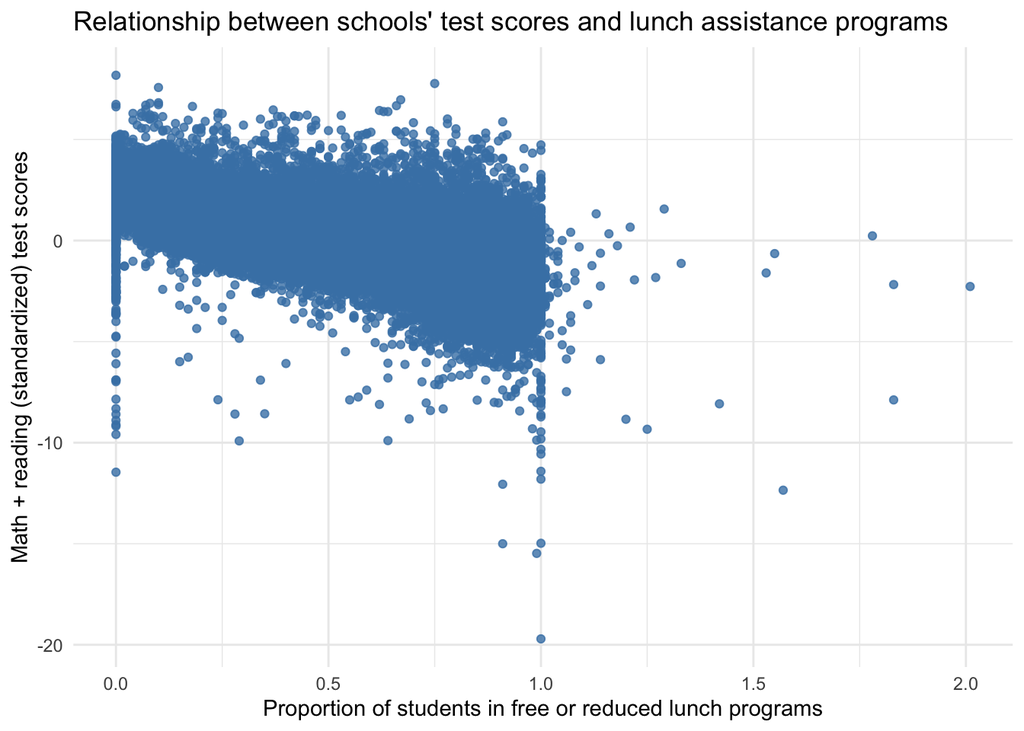

```r
# there really shouldn't be any x values above 1 (more than 100% of students)
# I am going to ignore for now in the interest of time

ggplot(schools) +
  geom_point(aes(x = free_lunch_proportion + reduced_lunch_proportion,
                 y = standardized_math_score + standardized_reading_score),
             alpha = 0.8, color = "steelblue") +
  labs(title = "Relationship between schools' test scores and lunch assistance programs",
       x = "Proportion of students in free or reduced lunch programs",
       y = "Math + reading (standardized) test scores")
```

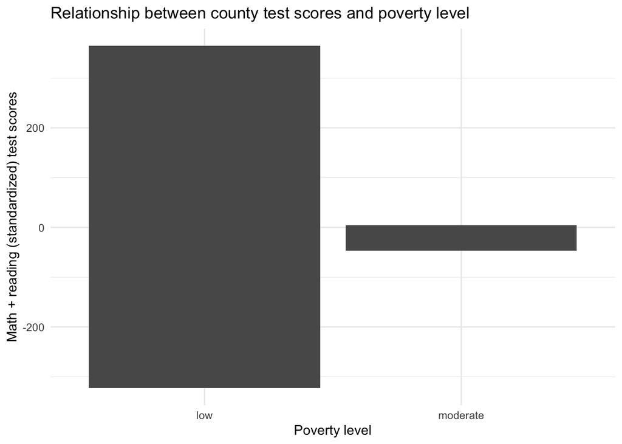

```r
ggplot(county_totals) +
  geom_col(aes(x = poverty_group, y = standardized_math_score + standardized_reading_score)) +
  labs(title = "Relationship between county test scores and poverty level",
       x = "Poverty level",
       y = "Math + reading (standardized) test scores")
```

I think it makes more sense to compare poverty frequency directly, instead of the buckets:

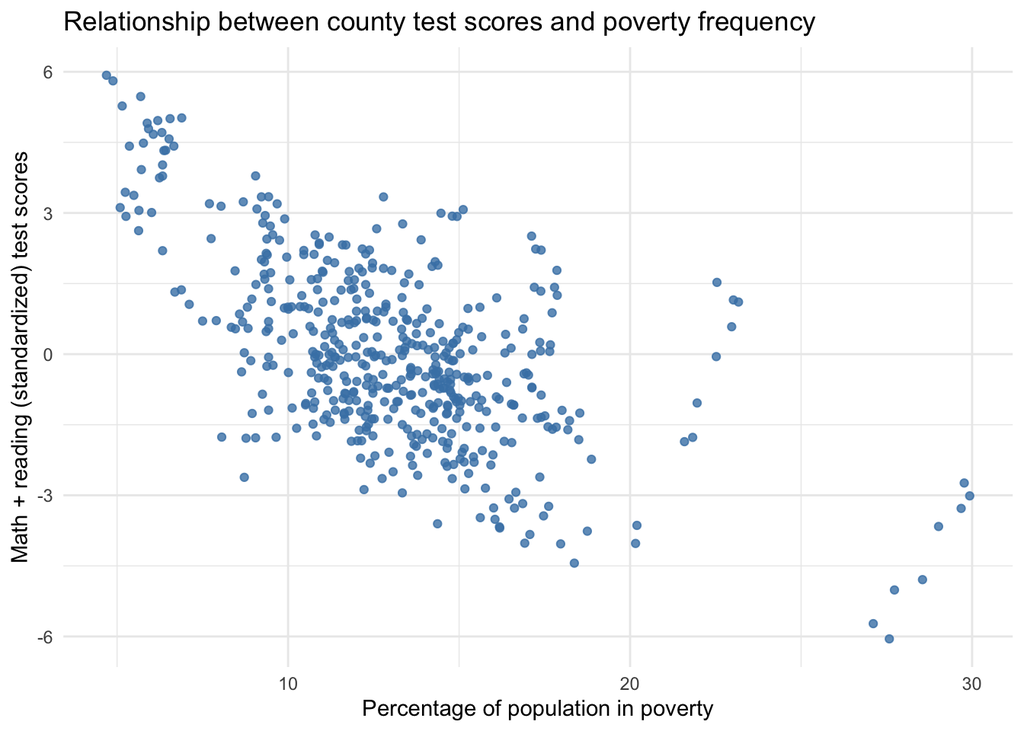

```r
ggplot(county_totals) +
  geom_point(aes(x = round(100 * poverty_proportion, 2),
                 y = standardized_math_score + standardized_reading_score),
             alpha = 0.8, color = "steelblue") +
  labs(title = "Relationship between county test scores and poverty frequency",
       x = "Percentage of population in poverty",
       y = "Math + reading (standardized) test scores")
```

#### Task 7: Answering questions

Using the skills you have learned in the past three days, tackle the following question:

> What can the data tell us about the relationship between poverty and test performance in New York public schools? Has this relationship changed over time? Is this relationship at all moderated by access to free/reduced price lunch?

You may use summary tables, statistical models, and/or data visualization in pursuing an answer to this question. Feel free to build on the tables and plots you generated above in Tasks 5 and 6.

Given the short time period, any answer will of course prove incomplete. The goal of this task is to give you some room to play around with the skills you’ve just learned. Don’t hesitate to try something even if you don’t feel comfortable with it yet. Do as much as you can in the time allotted.

Answer:

It seems clear based on the last graph that there is a fairly strong, negative relationship between test scores and poverty frequency. That is, counties with higher prevalence of poverty tend to score worse on standardized tests, after controlling for year-to-year fluctuations in the absolute scores of the tests. However, is this trend consistent over time? Again, it seems so:

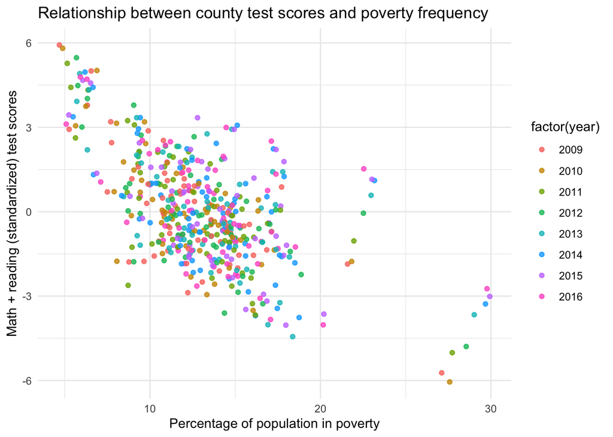

```r
ggplot(county_totals) +
  geom_point(aes(x = round(100 * poverty_proportion, 2),
                 y = standardized_math_score + standardized_reading_score,
                 color = factor(year)),
             alpha = 0.8) +
  labs(title = "Relationship between county test scores and poverty frequency",
       x = "Percentage of population in poverty",
       y = "Math + reading (standardized) test scores")
```

Separating based on year (to see more clearly):

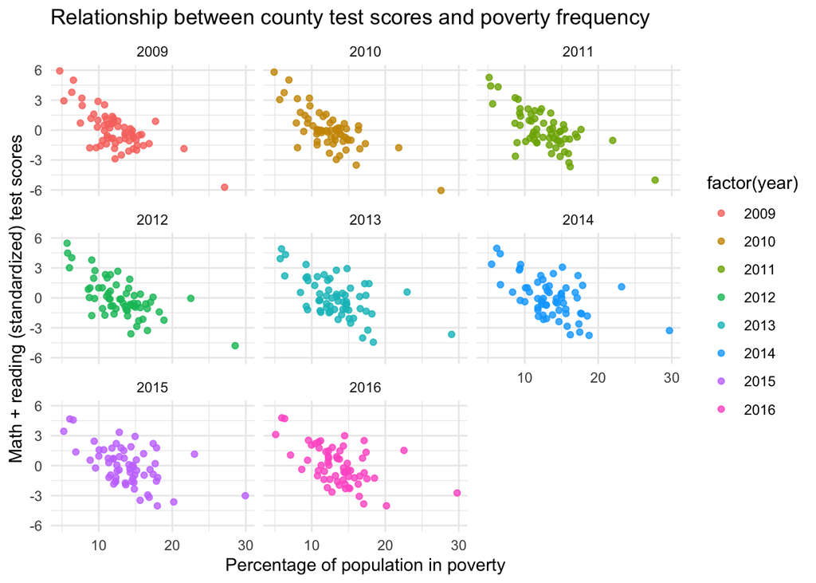

```r
ggplot(county_totals) +
  geom_point(aes(x = round(100 * poverty_proportion, 2),
                 y = standardized_math_score + standardized_reading_score,
                 color = factor(year)),
             alpha = 0.8) +
  facet_wrap(~ year) +
  labs(title = "Relationship between county test scores and poverty frequency",
       x = "Percentage of population in poverty",
       y = "Math + reading (standardized) test scores")
```

Though, is this relationship affected by lunch assistance programs? We can see from the plot below that lunch assistance and poverty tend to occur together. In addition, the highest test scores are located in the bottom-left corner (lowest frequencies of both poverty and lunch assistance), and tend to decrease as poverty and/or lunch assistance increase.

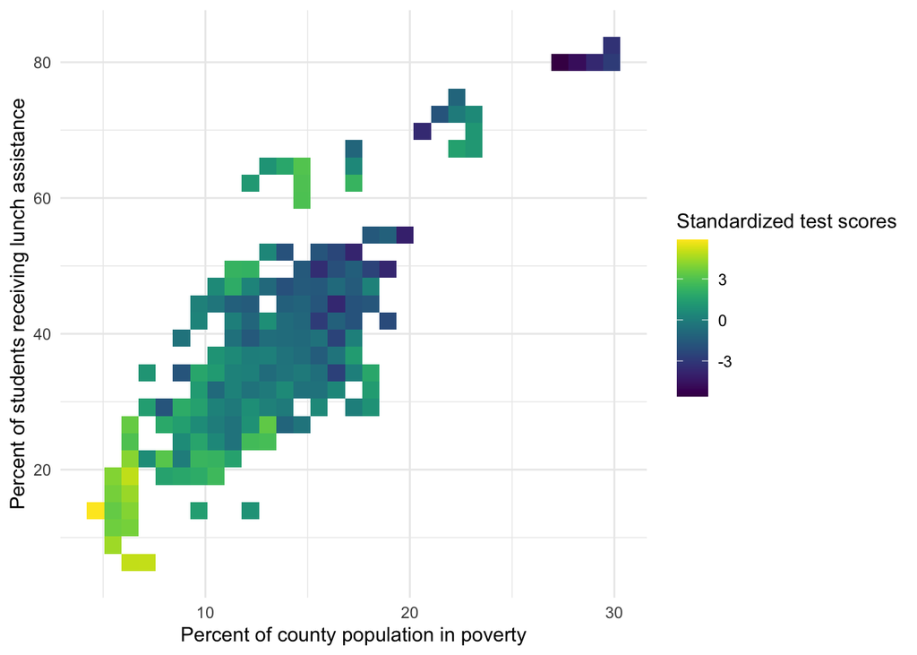

```r
ggplot(county_totals, aes(x = round(100 * poverty_proportion, 2),
                          y = round(100 * county_free_lunch_proportion, 2),
                          z = standardized_math_score + standardized_reading_score)) +
  stat_summary_2d() +
  geom_point(shape = 1, color = "white", alpha = 0) +
  viridis::scale_fill_viridis(name = "Standardized test scores") +
  labs(x = "Percent of county population in poverty",
       y = "Percent of students receiving lunch assistance")
```

## Github submission

When you have completed the exercise, save your Markdown file in the `submissions` folder of your forked repo using this naming convention: `FinalRExercise_LastnameFirstname.Rmd`. Commit changes periodically, and push commits when you are done.

You can optionally create a pull request to submit this file (and other exercise files from the bootcamp sessions) to the base repo that lives in the MSiA organization. If you would like to do this, make sure that all new files you have created are in the `submissions` folder, and then create a pull request that asks to merge changes from your forked repo to the base repo.

## Reminders

- Remember to **load necessary packages**.
- Remember to **comment extensively** in your code. Since you will be working in an RMarkdown file, you can describe your workflow in the text section. But you should also comment within all of your code chunks.
- Attempt to knit your Markdown file into HTML format before committing it to Github. Troubleshoot any errors with the knit process by checking the lines referred to in the error messages.